# Bike Sharing Dataset - Exploratary Data Analysis

Load library and dataset

```r
library(ggplot2)
library(tidyverse)
library(plyr)
library(tidyr)
library(dplyr)
library(lattice)
library(lubridate)
library(lettercase)
library(reshape2)
library(caret)
library(plotly)
library(GGally)
library(openxlsx)
library(PerformanceAnalytics)

setwd("C:/Users/Alvin/Documents/WorkDirectory")
bikeshare <- read.csv("bikes_2011.csv",header=T, colClasses="character") #raw bike_2011 dataset
```

Analyse raw data structure - non-visual analysis

```r
class(bikeshare)
```

```
## [1] "data.frame"
```

```r
dim(bikeshare)
```

```
## [1] 8645   17
```

```r
names(bikeshare)
```

```
##  [1] "instant"    "dteday"     "season"     "yr"         "mnth"
##  [6] "hr"         "holiday"    "weekday"    "workingday" "weathersit"
## [11] "temp"       "atemp"      "hum"        "windspeed"  "casual"
## [16] "registered" "cnt"
```

```r
glimpse(bikeshare)
```

```
## Observations: 8,645
## Variables: 17
## $ instant    <chr> "1", "2", "3", "4", "5", "6", "7", "8", "9", "10", ...
## $ dteday     <chr> "2011-01-01", "2011-01-01", "2011-01-01", "2011-01-...
## $ season     <chr> "1", "1", "1", "1", "1", "1", "1", "1", "1", "1", "...
## $ yr         <chr> "0", "0", "0", "0", "0", "0", "0", "0", "0", "0", "...
## $ mnth       <chr> "1", "1", "1", "1", "1", "1", "1", "1", "1", "1", "...
## $ hr         <chr> "0", "1", "2", "3", "4", "5", "6", "7", "8", "9", "...
## $ holiday    <chr> "0", "0", "0", "0", "0", "0", "0", "0", "0", "0", "...
## $ weekday    <chr> "6", "6", "6", "6", "6", "6", "6", "6", "6", "6", "...
## $ workingday <chr> "0", "0", "0", "0", "0", "0", "0", "0", "0", "0", "...
## $ weathersit <chr> "1", "1", "1", "1", "1", "2", "1", "1", "1", "1", "...
## $ temp       <chr> "0.24", "0.22", "0.22", "0.24", "0.24", "0.24", "0....
## $ atemp      <chr> "0.2879", "0.2727", "0.2727", "0.2879", "0.2879", "...
## $ hum        <chr> "0.81", "0.8", "0.8", "0.75", "0.75", "0.75", "0.8"...
## $ windspeed  <chr> "0.0", "0.0", "0.0", "0.0", "0.0", "0.0896", "0.0",...
## $ casual     <chr> "3", "8", "5", "3", "0", "0", "2", "1", "1", "8", "...
## $ registered <chr> "13", "32", "27", "10", "1", "1", "0", "2", "7", "6...
## $ cnt        <chr> "16", "40", "32", "13", "1", "1", "2", "3", "8", "1...
```

```r
summary(bikeshare)
```

```
##    instant             dteday             season
##  Length:8645        Length:8645        Length:8645
##  Class :character   Class :character   Class :character
##  Mode  :character   Mode  :character   Mode  :character
##       yr                mnth                hr
##  Length:8645        Length:8645        Length:8645
##  Class :character   Class :character   Class :character
##  Mode  :character   Mode  :character   Mode  :character
##    holiday            weekday           workingday
##  Length:8645        Length:8645        Length:8645
##  Class :character   Class :character   Class :character
##  Mode  :character   Mode  :character   Mode  :character
##   weathersit            temp              atemp
##  Length:8645        Length:8645        Length:8645
##  Class :character   Class :character   Class :character
##  Mode  :character   Mode  :character   Mode  :character
##      hum             windspeed            casual
##  Length:8645        Length:8645        Length:8645
##  Class :character   Class :character   Class :character
##  Mode  :character   Mode  :character   Mode  :character
##   registered            cnt
##  Length:8645        Length:8645
##  Class :character   Class :character
##  Mode  :character   Mode  :character
```

Data preparation and cleaning

```r
any(is.na(bikeshare)) # No missing data
```

```
## [1] FALSE
```

```r
#0 or more (*) spaces (\\s) between beginning (^) and end ($) of string
any(grepl("^\\s*$",bikeshare)) # No space before or after an input in each cell
```

```
## [1] FALSE
```

Covert variables type (characters, numeric, integer, factor, logical)

```r
bikeshare$instant <- as.numeric(bikeshare$instant)
bikeshare$dteday <- ymd(bikeshare$dteday) #issue with date format
bikeshare$season <- as.numeric(bikeshare$season)
bikeshare$hr <- as.numeric(bikeshare$hr)
bikeshare$holiday <- as.integer(bikeshare$holiday)
bikeshare$workingday <- as.logical(as.integer(bikeshare$workingday))
bikeshare$weathersit <- as.numeric(bikeshare$weathersit)
bikeshare$temp <- as.numeric(bikeshare$temp)
bikeshare$atemp <- as.numeric(bikeshare$atemp)
bikeshare$hum <- as.numeric(bikeshare$hum)
bikeshare$windspeed <- as.numeric(bikeshare$windspeed)
bikeshare$casual <- as.numeric(bikeshare$casual)
bikeshare$registered <- as.numeric(bikeshare$registered)
bikeshare$cnt <- as.numeric(bikeshare$cnt)
bikeshare$weekday <- as.integer(bikeshare$weekday)

# Convert variables "year", "month" and "date" to Date format
year <- format(bikeshare$dteday,"%y")
month <- format(bikeshare$dteday,"%m")
day <- format(bikeshare$dteday,"%a")

# Convert feeling temperature to degree celsius with formula atemp = (t-t_min)/(t_max-t_min) where t_min = -16 and t_max = 50
a_temp <- (bikeshare$atemp*66)-16

bikeshare_1 <- bikeshare %>%
  mutate(.,yr = year) %>%
  mutate(.,mnth = month) %>%
  mutate(.,weekday_char = day) %>%
  mutate(.,cnt1 = bikeshare$registered + bikeshare$casual) %>%   #calculate total demand by sum of registered+casual user
  mutate(., atemp = a_temp)
```

Check if cnt matches the sum of registered & casual bike user

```r
check_cnt <- bikeshare_1 %>%
  select(cnt, cnt1) %>%
  mutate(., validate = ifelse(cnt == cnt1, TRUE, FALSE))

which(grepl(FALSE, check_cnt$validate)) #conclusion: not conflicting values found between cnt and sum of registered & casual bike user
```

```
## integer(0)
```

Create new column for holiday + weekend (non-working day)

```r
bikeshare_2 <- bikeshare_1 %>%
  mutate(.,nonworking = if_else(
    bikeshare_1$holiday == 1, "Yes", ifelse(
    bikeshare_1$weekday == 6, "Yes", ifelse(
      bikeshare_1$weekday == 0, "Yes", "No"
    )))) %>%
  select(-cnt1)

glimpse(bikeshare_2) #new class
```

```
## Observations: 8,645
## Variables: 19
## $ instant      <dbl> 1, 2, 3, 4, 5, 6, 7, 8, 9, 10, 11, 12, 13, 14, 15...
## $ dteday       <date> 2011-01-01, 2011-01-01, 2011-01-01, 2011-01-01, ...
## $ season       <dbl> 1, 1, 1, 1, 1, 1, 1, 1, 1, 1, 1, 1, 1, 1, 1, 1, 1...
## $ yr           <chr> "11", "11", "11", "11", "11", "11", "11", "11", "...
## $ mnth         <chr> "01", "01", "01", "01", "01", "01", "01", "01", "...
## $ hr           <dbl> 0, 1, 2, 3, 4, 5, 6, 7, 8, 9, 10, 11, 12, 13, 14,...
## $ holiday      <int> 0, 0, 0, 0, 0, 0, 0, 0, 0, 0, 0, 0, 0, 0, 0, 0, 0...
## $ weekday      <int> 6, 6, 6, 6, 6, 6, 6, 6, 6, 6, 6, 6, 6, 6, 6, 6, 6...
## $ workingday   <lgl> FALSE, FALSE, FALSE, FALSE, FALSE, FALSE, FALSE, ...
## $ weathersit   <dbl> 1, 1, 1, 1, 1, 2, 1, 1, 1, 1, 1, 1, 1, 2, 2, 2, 2...
## $ temp         <dbl> 0.24, 0.22, 0.22, 0.24, 0.24, 0.24, 0.22, 0.20, 0...
## $ atemp        <dbl> 3.0014, 1.9982, 1.9982, 3.0014, 3.0014, 1.0016, 1...
## $ hum          <dbl> 0.81, 0.80, 0.80, 0.75, 0.75, 0.75, 0.80, 0.86, 0...
## $ windspeed    <dbl> 0.0000, 0.0000, 0.0000, 0.0000, 0.0000, 0.0896, 0...
## $ casual       <dbl> 3, 8, 5, 3, 0, 0, 2, 1, 1, 8, 12, 26, 29, 47, 35,...
## $ registered   <dbl> 13, 32, 27, 10, 1, 1, 0, 2, 7, 6, 24, 30, 55, 47,...
## $ cnt          <dbl> 16, 40, 32, 13, 1, 1, 2, 3, 8, 14, 36, 56, 84, 94...
## $ weekday_char <chr> "Sat", "Sat", "Sat", "Sat", "Sat", "Sat", "Sat", ...
## $ nonworking   <chr> "Yes", "Yes", "Yes", "Yes", "Yes", "Yes", "Yes", ...
```

```r
summary(bikeshare_2) #outliers
```

```
##     instant         dteday               season           yr
##  Min.   :   1   Min.   :2011-01-01   Min.   :1.000   Length:8645
##  1st Qu.:2162   1st Qu.:2011-04-04   1st Qu.:2.000   Class :character
##  Median :4323   Median :2011-07-04   Median :3.000   Mode  :character
##  Mean   :4323   Mean   :2011-07-03   Mean   :2.514
##  3rd Qu.:6484   3rd Qu.:2011-10-02   3rd Qu.:3.000
##  Max.   :8645   Max.   :2011-12-31   Max.   :4.000
##      mnth                 hr           holiday           weekday
##  Length:8645        Min.   : 0.00   Min.   :0.00000   Min.   :0.000
##  Class :character   1st Qu.: 6.00   1st Qu.:0.00000   1st Qu.:1.000
##  Mode  :character   Median :12.00   Median :0.00000   Median :3.000
##                     Mean   :11.57   Mean   :0.02765   Mean   :3.013
##                     3rd Qu.:18.00   3rd Qu.:0.00000   3rd Qu.:5.000
##                     Max.   :23.00   Max.   :1.00000   Max.   :6.000
##  workingday        weathersit         temp            atemp
##  Mode :logical   Min.   :1.000   Min.   :0.0200   Min.   :-16.000
##  FALSE:2734      1st Qu.:1.000   1st Qu.:0.3200   1st Qu.:  5.001
##  TRUE :5911      Median :1.000   Median :0.5000   Median : 15.997
##                  Mean   :1.438   Mean   :0.4891   Mean   : 14.954
##                  3rd Qu.:2.000   3rd Qu.:0.6600   3rd Qu.: 24.999
##                  Max.   :4.000   Max.   :0.9600   Max.   : 50.000
##       hum           windspeed          casual        registered
##  Min.   :0.0000   Min.   :0.0000   Min.   :  0.0   Min.   :  0.0
##  1st Qu.:0.4900   1st Qu.:0.1045   1st Qu.:  3.0   1st Qu.: 26.0
##  Median :0.6500   Median :0.1940   Median : 14.0   Median : 90.0
##  Mean   :0.6434   Mean   :0.1912   Mean   : 28.6   Mean   :115.2
##  3rd Qu.:0.8100   3rd Qu.:0.2836   3rd Qu.: 38.0   3rd Qu.:168.0
##  Max.   :1.0000   Max.   :0.8507   Max.   :272.0   Max.   :567.0
##       cnt        weekday_char        nonworking
##  Min.   :  1.0   Length:8645        Length:8645
##  1st Qu.: 31.0   Class :character   Class :character
##  Median :109.0   Mode  :character   Mode  :character
##  Mean   :143.8
##  3rd Qu.:211.0
##  Max.   :651.0
```

Check number of users for outliers

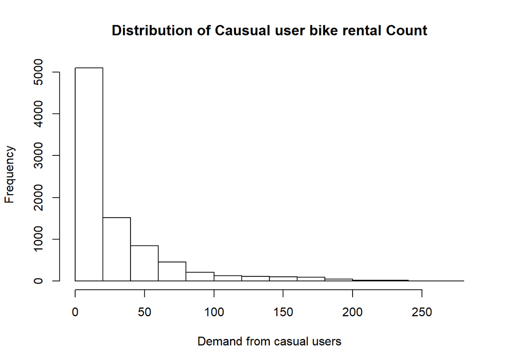

```r
hist(bikeshare$casual, breaks = 10, xlab = 'Demand from casual users', main = 'Distribution of Causual user bike rental Count')
```

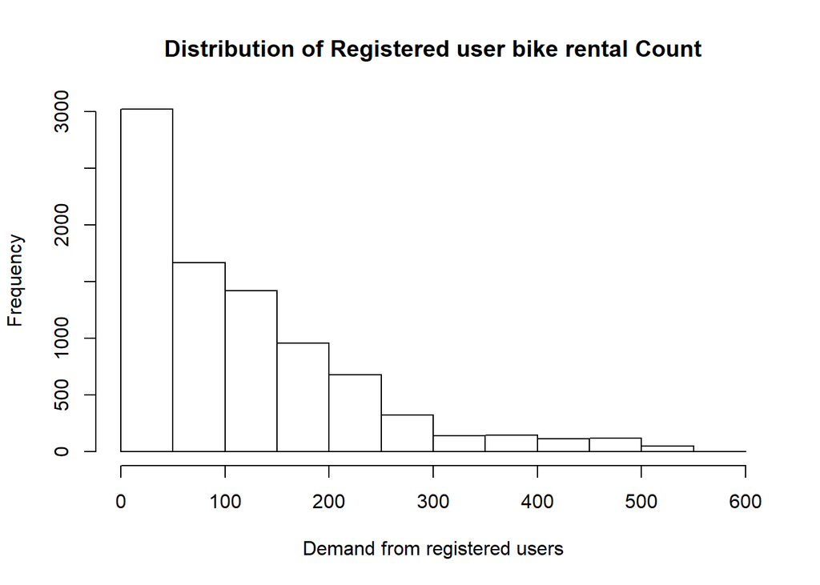

```r
# max is not an outlier

hist(bikeshare$registered, breaks = 20, xlab = 'Demand from registered users', main = 'Distribution of Registered user bike rental Count')
```

```r
# max is not an outlier

# Naming variables
cols <- c("index","date","season","year","month","hour","holiday","weekday","working.day","weather","temp","atemp", "humidity", "windspeed", "nonmember", "member", "totaldemand", "weekday.char", "nonworking" )
colnames(bikeshare_2) <- cols
glimpse(bikeshare_2) #new name
```

```
## Observations: 8,645
## Variables: 19
## $ index        <dbl> 1, 2, 3, 4, 5, 6, 7, 8, 9, 10, 11, 12, 13, 14, 15...
## $ date         <date> 2011-01-01, 2011-01-01, 2011-01-01, 2011-01-01, ...
## $ season       <dbl> 1, 1, 1, 1, 1, 1, 1, 1, 1, 1, 1, 1, 1, 1, 1, 1, 1...
## $ year         <chr> "11", "11", "11", "11", "11", "11", "11", "11", "...
## $ month        <chr> "01", "01", "01", "01", "01", "01", "01", "01", "...
## $ hour         <dbl> 0, 1, 2, 3, 4, 5, 6, 7, 8, 9, 10, 11, 12, 13, 14,...
## $ holiday      <int> 0, 0, 0, 0, 0, 0, 0, 0, 0, 0, 0, 0, 0, 0, 0, 0, 0...
## $ weekday      <int> 6, 6, 6, 6, 6, 6, 6, 6, 6, 6, 6, 6, 6, 6, 6, 6, 6...
## $ working.day  <lgl> FALSE, FALSE, FALSE, FALSE, FALSE, FALSE, FALSE, ...
## $ weather      <dbl> 1, 1, 1, 1, 1, 2, 1, 1, 1, 1, 1, 1, 1, 2, 2, 2, 2...
## $ temp         <dbl> 0.24, 0.22, 0.22, 0.24, 0.24, 0.24, 0.22, 0.20, 0...
## $ atemp        <dbl> 3.0014, 1.9982, 1.9982, 3.0014, 3.0014, 1.0016, 1...
## $ humidity     <dbl> 0.81, 0.80, 0.80, 0.75, 0.75, 0.75, 0.80, 0.86, 0...
## $ windspeed    <dbl> 0.0000, 0.0000, 0.0000, 0.0000, 0.0000, 0.0896, 0...
## $ nonmember    <dbl> 3, 8, 5, 3, 0, 0, 2, 1, 1, 8, 12, 26, 29, 47, 35,...
## $ member       <dbl> 13, 32, 27, 10, 1, 1, 0, 2, 7, 6, 24, 30, 55, 47,...
## $ totaldemand  <dbl> 16, 40, 32, 13, 1, 1, 2, 3, 8, 14, 36, 56, 84, 94...
## $ weekday.char <chr> "Sat", "Sat", "Sat", "Sat", "Sat", "Sat", "Sat", ...
## $ nonworking   <chr> "Yes", "Yes", "Yes", "Yes", "Yes", "Yes", "Yes", ...
```

Analysis

Distribution of total bike rental count

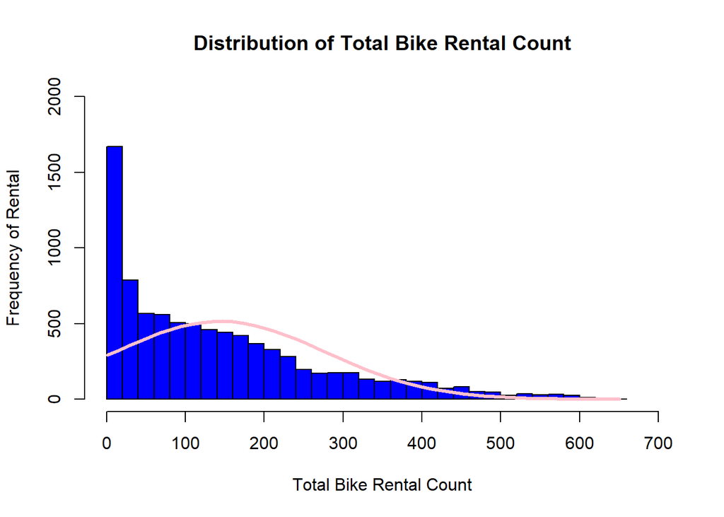

```r
bikerentalcount = hist(bikeshare$cnt, breaks = 25, ylab = 'Frequency of Rental', ylim = c(0,2000), xlim = c(0, 700), xlab = 'Total Bike Rental Count', main = 'Distribution of Total Bike Rental Count', col = 'blue' )

xfit = seq(min(bikeshare$cnt),max(bikeshare$cnt), length = 50)
yfit = dnorm(xfit, mean =mean(bikeshare$cnt),sd=sd(bikeshare$cnt))
yfit = yfit*diff(bikerentalcount$mids[1:2])*length(bikeshare$cnt)
lines(xfit,yfit, col='pink', lwd= 3)
```

Question 1 - How does each variable affect the demand for bike rental?

Prepare summary by total demand grouped by “month” and “weather”

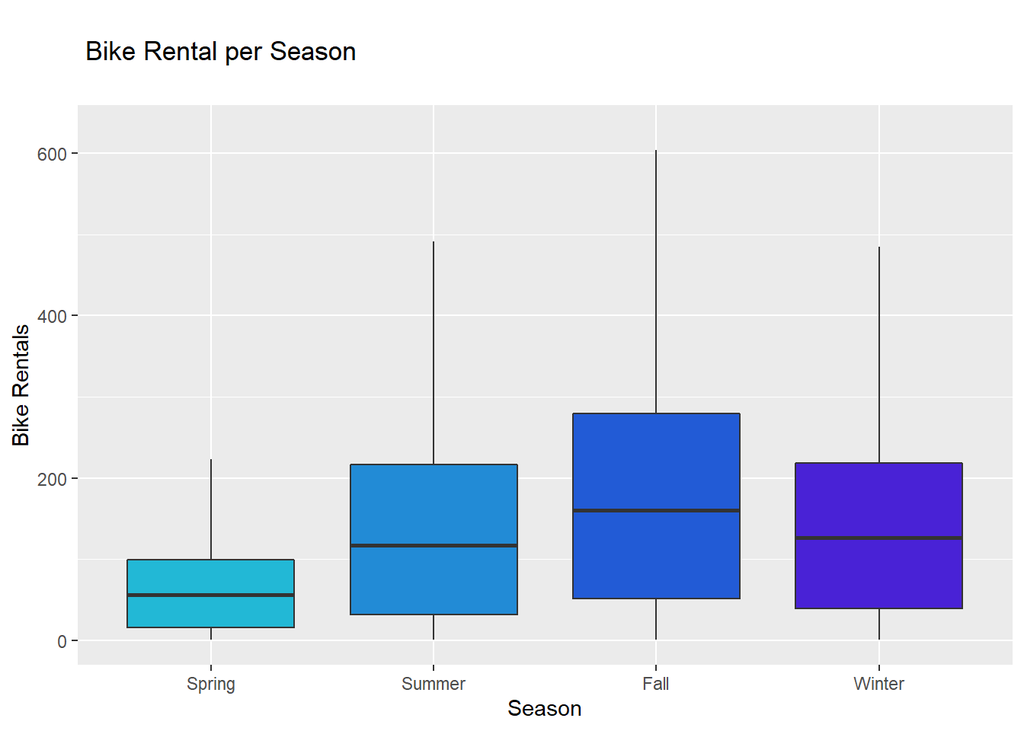

```r
count_summary <- ddply(bikeshare_2,.(season, hour, month, weather, weekday), summarise,
      temperature = mean(atemp),
      humidity = mean(humidity),
      windspeed = mean(windspeed),
      count = mean(totaldemand))

# Factor 1: season
rename_season <- count_summary %>%
  mutate(., season = as.factor(season)) %>%
  mutate(., season = revalue(season,c("1"="Spring", "2"="Summer", "3"="Fall", "4" = "Winter"))) #rename the levels in season( spring = 1, summer = 2, fall =3, winter =4)

ggplot(rename_season, aes(x = season, y = count, fill = factor(season))) +
  geom_boxplot(outlier.color = adjustcolor("black", alpha.f = 0), na.rm = TRUE) +
  ylab("Bike Rentals") +
  xlab("Season") +
  ggtitle("\n Bike Rental per Season \n") +
  scale_fill_manual(values = c("#22b8d6", "#228bd6", "#225bd6", "#4922d6"),
                    name = "Season:",
                    breaks = c(1, 2, 3, 4),
                    labels = c("Spring", "Summer", "Fall", "Winter"))
```

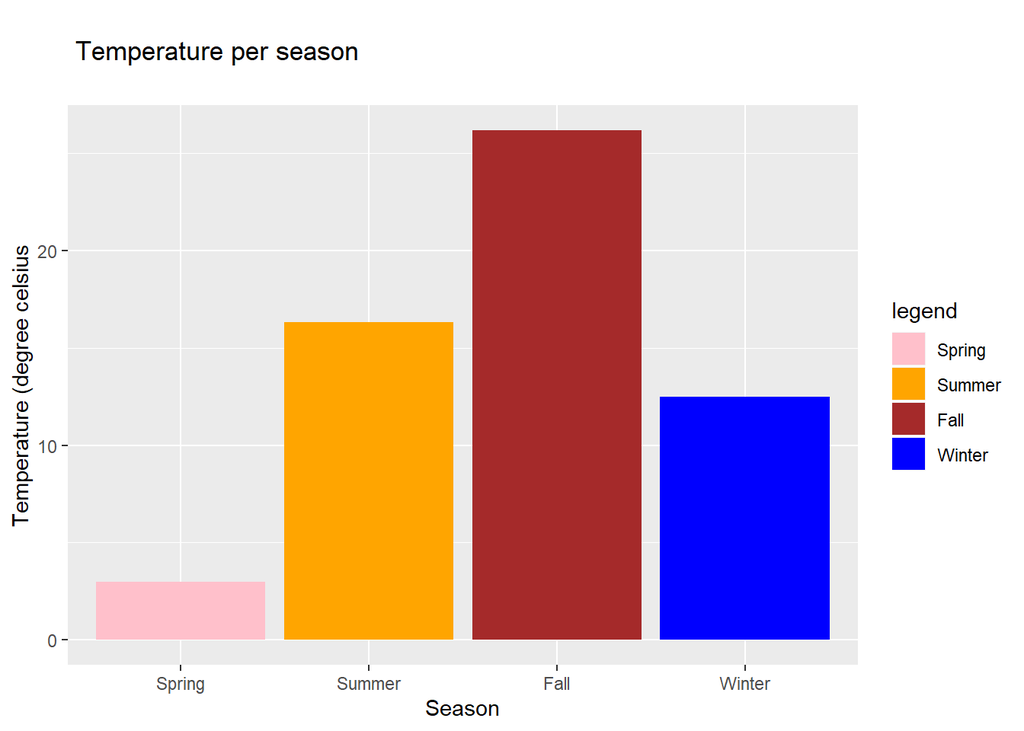

```r
# Plot avg temperature per season
rename_season1 <- count_summary %>%
  select(season, temperature) %>%
  mutate(., season = as.factor(season)) %>%
  mutate(., season = revalue(season,c("1"="Spring", "2"="Summer", "3"="Fall", "4" = "Winter"))) #rename the levels in season( spring = 1, summer = 2, fall =3, winter =4)

avg_temp <- rename_season1 %>%
  group_by(season)%>%
  summarise(temp = mean(temperature)) #calculate avg temperature per season

ggplot(avg_temp, aes(x = season, y = temp, fill = season)) +
  geom_col() +
  xlab("Season") +
  ylab("Temperature (degree celsius") +
  ggtitle("\n Temperature per season \n") +
  scale_fill_manual("legend", values = c("Spring" = "pink", "Summer" = "orange", "Fall" = "brown", "Winter" = "blue"))
```

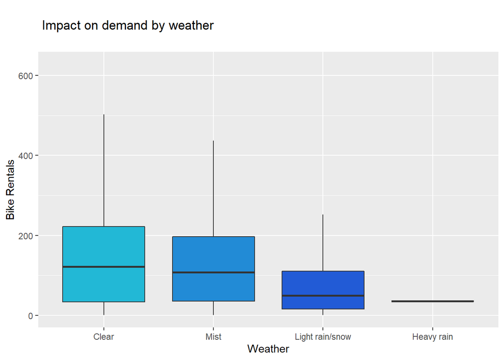

```r
# Spring has the least demand >> demand is affected largely by weather conditions


# Factor 2: weather
rename_weather <- count_summary %>%
  mutate(., weather = as.factor(weather)) %>%
  mutate(., weather = revalue(weather,c("1"="Clear", "2"="Mist", "3"="Light rain/snow", "4" = "Heavy rain"))) #rename the levels in weather( clear = 1, mist = 2, light rain =3, heavy rain =4)

ggplot(rename_weather, aes(x = weather, y = count, fill = factor(weather))) +
  geom_boxplot(outlier.color = adjustcolor("black", alpha.f = 0), na.rm = TRUE) +
  ylab("Bike Rentals") +
  xlab("Weather") +
  ggtitle("\n Impact on demand by weather \n") +
  scale_fill_manual(values = c("#22b8d6", "#228bd6", "#225bd6", "#4922d6"),
                    name = "Weather:",
                    breaks = c(1, 2, 3, 4),
                    labels = c("Clear", "Mist", "Light snow"
                             , "Heavy rain"))
```

Adverse weather conditions (heavy rain) significantly affects demand

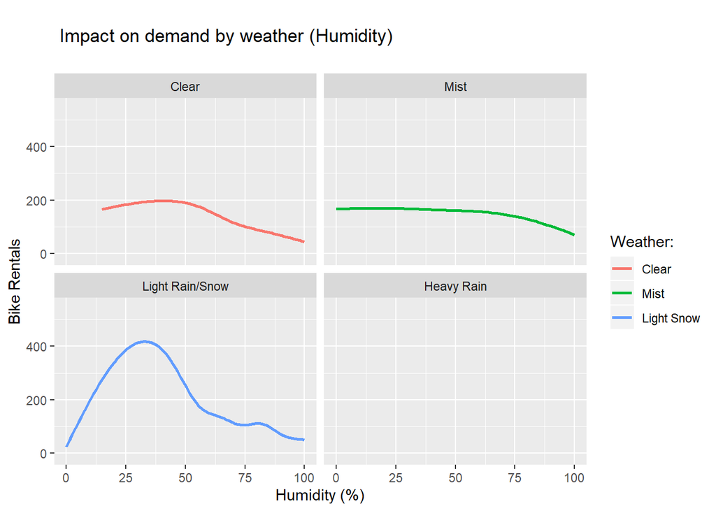

```r
# Secondary factor 2.1: Humidity
weather_names <- c(
  "1" = "Clear",
  "2" = "Mist",
  "3" = "Light Rain/Snow",
  "4" = "Heavy Rain")

ggplot(count_summary, aes(x = humidity*100, y = count, color = factor(weather))) +
  geom_smooth(fill = NA, size = 1, method="gam", formula = y ~s(x)) +
  xlab("Humidity (%)") +
  ylab("Bike Rentals") +
  ggtitle("\n Impact on demand by weather (Humidity) \n") +
  scale_color_discrete(name = "Weather:",
                       breaks = c(1, 2, 3, 4),
                       labels = c("Clear",
                                  "Mist",
                                  "Light Snow",
                                  "Heavy Rain")) +
  facet_wrap(~ weather, labeller = as_labeller(weather_names))
```

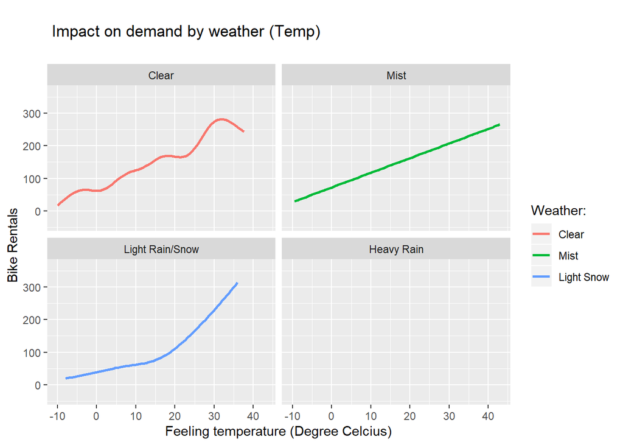

```r
# Higher relative humidity leads to lower bike demand

# Secondary factor 2.2: Temperature
ggplot(count_summary, aes(x = temperature, y = count, color = factor(weather))) +
  geom_smooth(fill = NA, size = 1, method="gam", formula = y ~s(x)) +
  xlab("Feeling temperature (Degree Celcius)") +
  ylab("Bike Rentals") +
  ggtitle("\n Impact on demand by weather (Temp) \n") +
  scale_color_discrete(name = "Weather:",
                       breaks = c(1, 2, 3),
                       labels = c("Clear",
                                  "Mist",
                                  "Light Snow")) +
  facet_wrap(~ weather, labeller = as_labeller(weather_names))
```

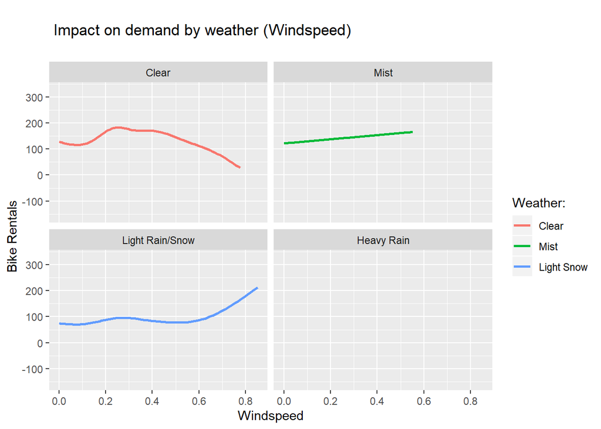

```r
# Lower temper leads to lower demand. Optimal temperature with higher demand = 30-40 celsius

# Secondary factor 2.3: Windspeed

ggplot(count_summary, aes(x = windspeed, y = count, color = factor(weather))) +
  geom_smooth(fill = NA, size = 1, method="gam", formula = y ~s(x)) +
  xlab("Windspeed") +
  ylab("Bike Rentals") +
  ggtitle("\n Impact on demand by weather (Windspeed) \n") +
  scale_color_discrete(name = "Weather:",
                       breaks = c(1, 2, 3),
                       labels = c("Clear",
                                  "Mist",
                                  "Light Snow")) +
  facet_wrap(~ weather, labeller = as_labeller(weather_names))
```

Factor 3: holiday and weekend vs workday

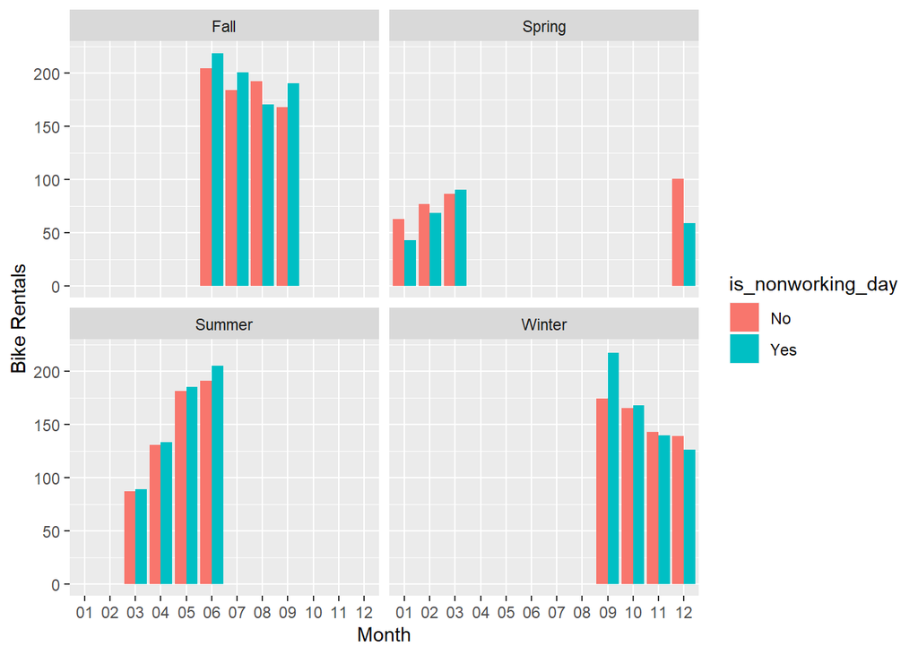

```r
temp1 <- bikeshare_2 %>%
  select(date, nonworking, totaldemand, season) %>%
  group_by(date, nonworking) %>%
  mutate(., month = as.factor(format(date, "%m"))) %>%
  mutate(., season = as.factor(season))

temp2 <- aggregate(temp1[,3], list(temp1$season, temp1$nonworking, temp1$month), mean)

# Calculate average daily demand for bike rental per working vs nonworking dat per month
temp3 <- temp2 %>%
  rename(is_nonworking_day = Group.2,) %>%
  rename(season = Group.1) %>%
  rename(month = Group.3)

season_names <- temp3 %>%
  mutate(., season = revalue(season,c("1"="Spring", "2"="Summer", "3"="Fall", "4" = "Winter"))) #rename the levels in season( spring = 1, summer = 2, fall =3, winter =4)

ggplot(season_names, aes(x = month, y = totaldemand, fill = is_nonworking_day)) +
  geom_bar(stat = "identity", position='dodge') +
  ylab("Bike Rentals") +
  xlab("Month") +
  facet_wrap (~season)
```

Factor 4: hours of day

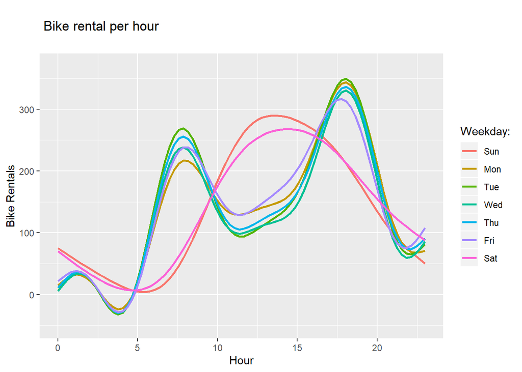

```r
ggplot(count_summary, aes(x = hour, y = count, color = factor(weekday))) +
  geom_smooth(fill = NA, size = 1, method="gam", formula = y ~s(x)) +
  xlab("Hour") +
  ylab("Bike Rentals") +
  ggtitle("\n Bike rental per hour\n") +
  scale_color_discrete(name = "Weekday:",
                       breaks = c(0, 1, 2, 3, 4, 5, 6),
                       labels = c("Sun",
                                  "Mon",
                                  "Tue",
                                  "Wed",
                                  "Thu",
                                  "Fri",
                                  "Sat"))
```

Question 2 - Which variables has the highest correlation (to find the most important factor)?

```r
Temp4 <- bikeshare_2 %>%
  mutate(., nonworking = ifelse(nonworking == "Yes", 1, 0)) %>%
  mutate(., month = as.numeric(month))

correlation_chart <- Temp4 %>%
  select(season, month, nonworking, weather, atemp, humidity, windspeed, weekday, hour, totaldemand)

glimpse(correlation_chart)
```

```
## Observations: 8,645
## Variables: 10
## $ season      <dbl> 1, 1, 1, 1, 1, 1, 1, 1, 1, 1, 1, 1, 1, 1, 1, 1, 1,...
## $ month       <dbl> 1, 1, 1, 1, 1, 1, 1, 1, 1, 1, 1, 1, 1, 1, 1, 1, 1,...
## $ nonworking  <dbl> 1, 1, 1, 1, 1, 1, 1, 1, 1, 1, 1, 1, 1, 1, 1, 1, 1,...
## $ weather     <dbl> 1, 1, 1, 1, 1, 2, 1, 1, 1, 1, 1, 1, 1, 2, 2, 2, 2,...
## $ atemp       <dbl> 3.0014, 1.9982, 1.9982, 3.0014, 3.0014, 1.0016, 1....
## $ humidity    <dbl> 0.81, 0.80, 0.80, 0.75, 0.75, 0.75, 0.80, 0.86, 0....
## $ windspeed   <dbl> 0.0000, 0.0000, 0.0000, 0.0000, 0.0000, 0.0896, 0....
## $ weekday     <int> 6, 6, 6, 6, 6, 6, 6, 6, 6, 6, 6, 6, 6, 6, 6, 6, 6,...
## $ hour        <dbl> 0, 1, 2, 3, 4, 5, 6, 7, 8, 9, 10, 11, 12, 13, 14, ...
## $ totaldemand <dbl> 16, 40, 32, 13, 1, 1, 2, 3, 8, 14, 36, 56, 84, 94,...
```

```r
coral_red = rgb(1.00,0.30,0.30); pumpkin = rgb(1.00,0.40,0.10); corn = rgb(1.00,0.90,0.40); red=rgb(1.00,0.00,0.00)
RtoWrange<-colorRampPalette(c(corn, red ))
WtoGrange<-colorRampPalette(c(coral_red, corn))

ggsave("00_correlation_matrix.png",
       ggplot(melt(cor(correlation_chart)), aes(x = Var1, y = Var2, fill = value)) +
         geom_tile() +
         scale_fill_gradient2("", low = WtoGrange(100), mid = RtoWrange(100), high = "gray") +
         geom_text(aes(label = round(value, 2))) +
         coord_flip() +
         ggtitle("\n Factor Correlation Matrix \n") +
         theme(plot.title = element_text(size = 14),
               axis.text.x = element_text(angle = 45, vjust = 0.6),
               axis.ticks.y = element_blank()) +
         xlab("") + ylab(""))
```

Question 3 - How can we forecast demand per day?

```r
model <- lm(count ~ hour + temperature + humidity , data = count_summary)
summary(model)
```

```
##
## Call:
## lm(formula = count ~ hour + temperature + humidity, data = count_summary)
##
## Residuals:
##     Min      1Q  Median      3Q     Max
## -235.55  -64.86  -19.70   39.87  430.57
##
## Coefficients:
##              Estimate Std. Error t value Pr(>|t|)
## (Intercept)   97.3490     6.9581   13.99   <2e-16 ***
## hour           5.5960     0.2247   24.91   <2e-16 ***
## temperature    5.0170     0.1376   36.46   <2e-16 ***
## humidity    -144.5287     8.2423  -17.54   <2e-16 ***
## ---
## Signif. codes:  0 '***' 0.001 '**' 0.01 '*' 0.05 '.' 0.1 ' ' 1
##
## Residual standard error: 102 on 4720 degrees of freedom
## Multiple R-squared:  0.3714, Adjusted R-squared:  0.371
## F-statistic: 929.6 on 3 and 4720 DF,  p-value: < 2.2e-16
```

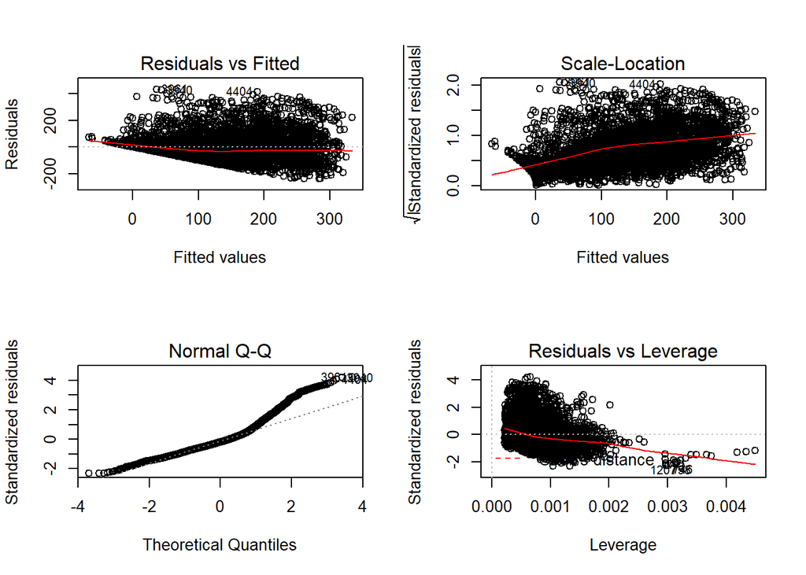

```r
layout(matrix(c(1,2,3,4),2,2))

plot(model)
```

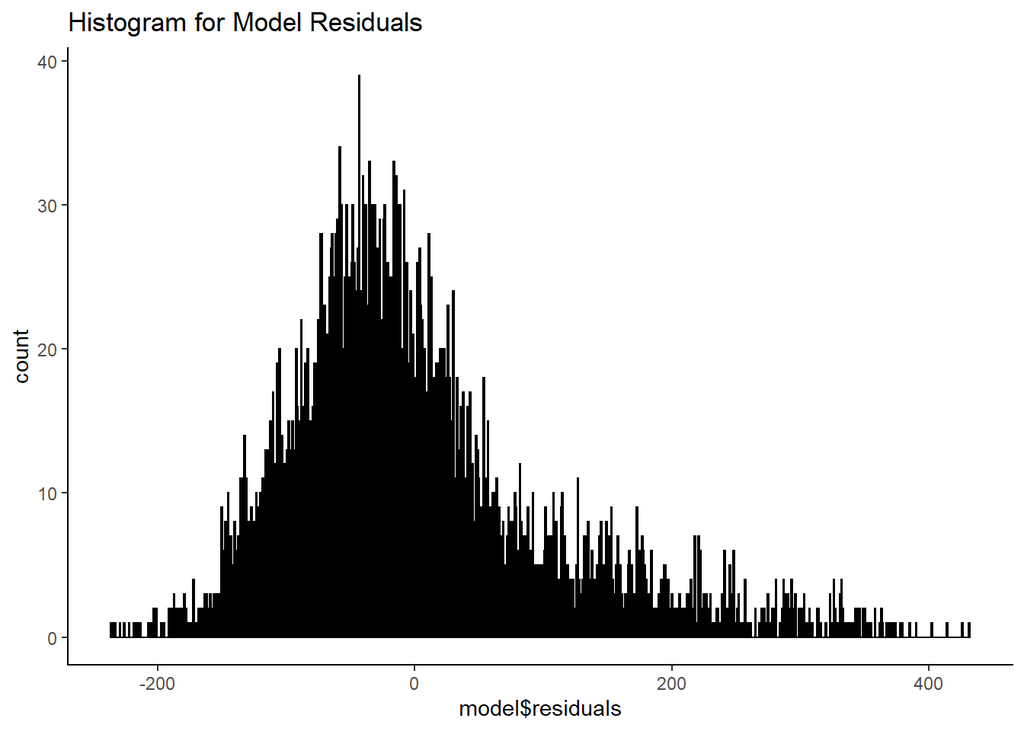

```r
ggplot(data=count_summary, aes(model$residuals)) +
  geom_histogram(binwidth = 1, color = "black", fill = "purple4") +
  theme(panel.background = element_rect(fill = "white"),
        axis.line.x=element_line(),
        axis.line.y=element_line()) +
  ggtitle("Histogram for Model Residuals")
```

Question 4 - Are there any difference in member/non-member renting behaviour?